# Análise de dados, séries temporais e aplicação do algoritmo Apriori em dados de vendas de loja do setor de informática.

**Aluna: Vanessa Velasco Cazeiro**

**Orientador: André Lúcio de Oliveira**

Esse notebook foi criado como parte do trabalho desenvolvido no âmbito da Monografia de Conclusão de Curso,  
como requisito para obtenção de grau de Bacharel em Engenharia da Computação na Universidade Veiga de Almeida.

**11/2022**

### Sumário

- Objetivo
- Metodologia
  - Bibliotecas Utilizadas
  - Funções Úteis
  - Leitura dos Dados
  - Tratamento dos Dados
  - Compreendendo os Dados
  - Séries Temporais e Prophet
    - Condicionamento
    - Implementação
  - Aplicação do Algoritmo Apriori
    - Condicionamento
    - Implementação
- Resultados e Discussões
  - Regras de Associação
  - Séries e Tendências Temporais

# Objetivos

O objetivo desse trabalho é explorar algumas das diversas ferramentas e boas práticas disponíveis no contexto da análise de dados, séries temporais e aplicação do algoritmo Apriori. O dado utilizado em questão foi gentilmente cedido por uma loja do setor de informática, correspondente aos registros de vendas entre 2018 e 2022. Seguindo uma ordenação lógica, o dado será tratado e condicionado para servir de base para uma série de análises que visam compreender padrões e comportamentos de vendas/clientes. Em outras palavras, o cerne desse trabalho é realizar uma revisão e aplicação geral de diversos métodos que englobe a conversão de um dado bruto, que anteriormente foi extraído de uma base de dados, para um produto final que auxilie tomadas de decisões da referida loja.  
Etapas:

Tratamento inicial para correção de erros grosseiros, estabelecimento de datatypes e organização temporal.

Exploração de ferramentas de compreensão dos dados.

Análise de série temporal e aplicação da biblioteca Prophet.

Aplicação de algoritmo Apriori.

# Metodologia

### Bibliotecas Utilizadas

```python
import pandas as pd
pd.options.display.max_rows = 3000
import numpy as np
import matplotlib.pyplot as plt
import matplotlib.dates as mdates
from mlxtend.preprocessing import TransactionEncoder
from mlxtend.frequent_patterns import apriori, association_rules
from collections import Counter
import datetime as dt
from dateutil.relativedelta import relativedelta
from fbprophet import Prophet
from sklearn.metrics import mean_squared_error
from math import sqrt
import math
import warnings
warnings.filterwarnings('ignore', category=DeprecationWarning)
warnings.filterwarnings('ignore')
```

### Funções Úteis

```python
# Aqui, é trocado o padrão ponto-vírgula brasileiro para o modelo americano.
def invertePontoVirgula(pandasSeries):
    '''
    Input pd.Series >> Padrão brasileiro:
    Vírgula é o separador decimal;
    Ponto é o separador de milhar.

    Output pd.Series >> Padrão americano:
    Vírgula é o separador de milhar;
    Ponto é o separador decimal.

    '''
    pandasSeries = pandasSeries.str.replace(',','|',regex=False)
    pandasSeries = pandasSeries.str.replace('.','' ,regex=False)
    pandasSeries = pandasSeries.str.replace('|','.',regex=False)

    return pandasSeries
```

```python
# Função criada para ver se todos os elementos de uma lista (A) estão contido em outra lista (B).
def isInList(A,B):
    if len(set(A).intersection(B)) == len(A):
        return True
    return False

# Calculando as relações que incluem somente o itemset indicado, tanto como antecedente quanto consequente.
def itemsetIndex(rules, B):
    index_list = []
    for i in range(len(rules)):
        A1 = rules['antecedents'][i]
        A2 = rules['consequents'][i]
        if (isInList(A1,B)==True) and (isInList(A2,B)==True):
            index_list.append(i)
    print(f'Quantidade de regras de associação totais: {len(rules)}')
    print(f'Quantidade de regras de associação somente com o itemset: {len(index_list)}')
    print(f'Lift médio das regras de associação: {np.round(rules.iloc[index_list].lift.mean(),2)}')
    print(f'Confidence médio das regras de associação: {np.round(rules.iloc[index_list].confidence.mean(),4)*100}%')
    print(f'Support total das regras de associação: {np.round(rules.iloc[index_list].support.sum(),4)*100}%')

    return index_list
```

```python
# Função criada para transformar uma lista de frases em uma string final que contém somente as palavras comuns a todas frases.
def findCommonWords(listOfSentences):

    # Get all words of all strings within the list
    allWords = []
    for sentence in listOfSentences:
        splitedSentence = sentence.split(' ')
        for word in splitedSentence:
            allWords.append(word)
    # Counting the words and finding the most common
    c = Counter(allWords)
    wordsDf = pd.DataFrame(c.most_common(),columns=['word','count'])
    if wordsDf['count'][0] == len(listOfSentences):
        commonWordsList = list(wordsDf['word'][np.where(wordsDf['count'] == len(listOfSentences))[0]])
    else:
        commonWordsList = list(wordsDf['word'][0:2])
    # Building the sentence
    sentence = ''
    for word in commonWordsList:
        sentence = sentence + ' ' + word
    sentence = sentence[1::]

    return sentence
```

### Leitura dos Dados

```python
data = pd.read_csv("premium.csv",sep=";",encoding="ANSI")
data.shape
```

```
(20205, 10)
```

```python
data.head()
```

|  | Pedido de Venda | Data de Emissão | Hora de Emissão | Produto | Nome do Produto | Preço Unitário | Preço de Custo | Quantidade de Item | Desconto | Total do Item |
| --- | --- | --- | --- | --- | --- | --- | --- | --- | --- | --- |
| 0 | 2.0 | 26/05/2018 | 11:09:27 | 212.0 | BATERIA IPHONE 5S | 150 | 35 | 1 | 75 | 75 |
| 1 | 2.0 | 26/05/2018 | 11:09:21 | 41.0 | PREMIUM CABLE LIGHTNING GRAFITE 1,2M | 89,9 | 39,5 | 1 | 0 | 89,9 |
| 2 | 4.0 | 29/05/2018 | 18:49:25 | 1.0 | CORTE DE CHIP | 10 | 0 | 1 | 0 | 10 |
| 3 | 3.0 | 29/05/2018 | 13:53:34 | 1.0 | CORTE DE CHIP | 10 | 0 | 1 | 0 | 10 |
| 4 | 6.0 | 06/06/2018 | 13:04:20 | 265.0 | FONTE VEICULAR DUAL USB 2.1A MAIS MANIA | 45 | 18,27 | 1 | 0 | 45 |

### Tratamento dos Dados

O dado foi importado imediatamente após ser extraído de um banco de dados (PostgreSQL). Portanto, ele necessita de uns ajustes, nomeadamente:

O dado veio no padrão brasileiro no que tange ao uso de pontos como separador do milhar e vírgulas dos decimais. Portanto, foi criada uma função (invertePontoVirgula) para converter para o padrão americano, onde o ponto é o separador decimal e a vírgula é o separador do milhar;

Estabelecer os datatypes para faciliar utilização do dado em etapas posteriores;

Consertar um problema no produto de código 1, o qual corresponde ao nome do produto 'ENTREGA' mas erroneamente possui algumas outras strings associadas. Essas linhas com informação duvidosa serão eliminadas.

```python
# Invertendo pontos e vírgulas
data["Preço Unitário"] = invertePontoVirgula(data["Preço Unitário"])
data["Preço de Custo"] = invertePontoVirgula(data["Preço de Custo"])
data["Desconto"]       = invertePontoVirgula(data["Desconto"]      )
data["Total do Item"]  = invertePontoVirgula(data["Total do Item"] )
```

```python
# Definindo datatypes
data["Pedido de Venda"]    = data["Pedido de Venda"]   .astype(float)
data["Data de Emissão"]    = pd.to_datetime(data["Data de Emissão"], format='%d/%m/%Y')
data["Hora de Emissão"]    = pd.to_datetime(data["Hora de Emissão"], format='%H:%M:%S')
data["Nome do Produto"]    = data["Nome do Produto"]   .astype(str)
data["Preço Unitário"]     = data["Preço Unitário"]    .astype(float)
data["Preço de Custo"]     = data["Preço de Custo"]    .astype(float)
data["Quantidade de Item"] = data["Quantidade de Item"].astype(int)
data["Desconto"]           = data["Desconto"]          .astype(float)
data["Total do Item"]      = data["Total do Item"]     .astype(float)
```

```python
# Consertando o Código do Produto == 1, em que originalmente corresponde ao Nome do Produto == "ENTREGA".
# Outros nomes de produto foram associados de forma errada ao mesmo Código do Produto.
# Vamos eliminar essas linhas que não contém dados confiáveis.

new_data_prod_1_different_ENTREGA = data.iloc[np.where((data["Produto"]==1) & (data["Nome do Produto"]!='ENTREGA'))]
for i in new_data_prod_1_different_ENTREGA.index:
    data = data.drop(index=i)
```

```python
# Ok, vamos ordenar o dataset final em relação à Data de Emissão.
data = data.sort_values(by=['Data de Emissão'],axis=0).reset_index(drop=True)
```

```python
data.info()
```

```
<class 'pandas.core.frame.DataFrame'>
RangeIndex: 20139 entries, 0 to 20138
Data columns (total 10 columns):
 #   Column              Non-Null Count  Dtype
---  ------              --------------  -----
 0   Pedido de Venda     20139 non-null  float64
 1   Data de Emissão     20139 non-null  datetime64[ns]
 2   Hora de Emissão     20139 non-null  datetime64[ns]
 3   Produto             20139 non-null  float64
 4   Nome do Produto     20139 non-null  object
 5   Preço Unitário      20139 non-null  float64
 6   Preço de Custo      20139 non-null  float64
 7   Quantidade de Item  20139 non-null  int32
 8   Desconto            20139 non-null  float64
 9   Total do Item       20139 non-null  float64
dtypes: datetime64[ns](2), float64(6), int32(1), object(1)
memory usage: 1.5+ MB
```

Todos os dados foram devidamente importados, datatypes estabelecidos, problemas corrigidos e não há campos nulos.

### Compreendendo os Dados

Será explorado algumas peculiaridades do dataset, como:

- Quantidades únicas de 'Pedido de Venda', 'Produto' e 'Nome do Produto'.
- Multiplas strings 'Nome do Produto' associadas a um único código ('Produto').

```python
print(f'Dimensões do dataset: {data.shape}\n')
for column in ['Pedido de Venda', 'Produto', 'Nome do Produto']:
    print(f'Quantidade de valores únicos da coluna {column}: {len(np.unique(data[column]))}')
```

```
Dimensões do dataset: (20139, 10)

Quantidade de valores únicos da coluna Pedido de Venda: 14744
Quantidade de valores únicos da coluna Produto: 1803
Quantidade de valores únicos da coluna Nome do Produto: 3672
```

Notadamente, é de se estranhar que a quantidade de valores únicos das colunas 'Produto' e 'Nome do Produto' seja diferente. Isso indica que um único código de produto pode conter mais de uma string associada.  
A justificativa para esse acontecimento é simples. Para cada venda registrada, existem produtos iguais mas de diferentes marcas, cores e características. Nesses casos o funcionário registra como um mesmo código de produto. Pegando como exemplo o Produto == 1.341 (célula abaixo), temos 6 strings de nomes distintos. **São todos HD SSD 480GB, mas de marcas diferentes. Logo, levam o mesmo código.** Essa questão vai apresentar uma peculiaridade na aplicação do algoritmo Apriori: não poderemos colocar os itemsets (subconjuntos de itens) referenciados pelos seus 'Nome de Produto' (strings), mas sim pelo seu código ('Produto').

```python
data['Nome do Produto'].iloc[np.where(data['Produto']==1.341)[0]].unique()
```

```
array(['HD SSD 480GB CRUCIAL', 'HD SSD 480GB SANDISK', 'HD SSD 480GB WD',
       'HD SSD 480GB WD / SANDISK', 'HD SSD 480GB HYUNDAY',
       'HD SSD 480GB WESTERN DIGITAL'], dtype=object)
```

O input do apriori será feito utilizando o **código do produto**. No entanto, para facilitar a compreensão e posterior interpretação dos dados, foi criada uma função chamada findCommonWords. Ela pega, para código de produto, a lista de strings correspondentes a todos os nomes registrados naquele código, como exemplificado na célula anterior. Dessa lista, a função extrai as strings mais comuns para cada elemento da lista. Por exemplo, as palavras mais comuns do produto 1.341 são 'HD SSD 480GB'.  
É importante ressaltar que, mesmo utilizando essa função para encontrar uma string única identificadora do produto, essa solução não é perfeita. Devido a isso, ela não pode servir de base para o input no algoritmo apriori, servindo apenas como ferramenta de compreensão e interpretação dos dados. O melhor identificador único segue sendo o código do produto.

```python
listOfSentences = data['Nome do Produto'].iloc[np.where(data['Produto']==1.341)[0]].unique()
findCommonWords(listOfSentences)
```

```
'HD SSD 480GB'
```

### Séries Temporais e Prophet

Uma **série temporal** é definida como um conjunto de observações realizadas num intervalo de tempo regular; e há uma relação de dependência entre observações vizinhas ([Ehlers, R.S. (2007)](http://www.leg.ufpr.br/~ehlers/)). Essas observações podem ser: o valor do fechamento de uma ação a cada 15 minutos, o peso corporal de um indivíduo ao longo de semanas, ou a quantidade de alunos formados em determinada instituição de ensino ao longo dos anos. No contexto do presente trabalho, a série temporal trata-se do montante (R$) total de vendas diárias em uma loja do setor de informática.  
Uma série temporal pode ser decomposta em componentes clássicas, como:

A tendência de longo prazo ou **Tendência (Trend)**. Indica uma direção generalista para a série.

As tendências de curto prazo, podendo ser:

**Variações Sazonais**, que são variações que ocorrem em intervalos regulares de tempo; ou

**Variações Cíclicas**, que são variações que ocorrem em intervalos irregulares de tempo.

Movimentos randômicos e aleatórios, ou **Ruído**.

```python
# Criando cópia do dataset
data_ = data.copy()
```

```python
print('Data de início dos registros:',data_['Data de Emissão'][0])
print('Data de fim dos registros:   ',data_['Data de Emissão'][len(data_)-1])
print('Intervalo temporal:          ',data_['Data de Emissão'][len(data_)-1] - data_['Data de Emissão'][0])
```

```
Data de início dos registros: 2018-05-26 00:00:00
Data de fim dos registros:    2022-09-12 00:00:00
Intervalo temporal:           1570 days 00:00:00
```

**CONDICIONAMENTO**

Inicialmente, os dados foram organizados em duas novas variáveis, chamadas serieTemporal e inputProphet. A primeira tem como objetivo visualização, apresentando um pandas.DataFrame organizado em [MultiIndex](https://pandas.pydata.org/pandas-docs/stable/user_guide/advanced.html), ferramenta que permite organização hierárquica de diferentes índices - no caso, **ano**, **mês** e **dia**. A segunda matriz, por sua vez, serve como input para o Prophet.

```python
# Criação do matriz da série temporal com MultiIndex
serieTemporal = data_[['Data de Emissão','Total do Item']].groupby([
    (data_['Data de Emissão'].dt.year),
    (data_['Data de Emissão'].dt.month),
    (data_['Data de Emissão'].dt.day)])['Total do Item'].agg(np.sum)
serieTemporal = pd.DataFrame(serieTemporal,columns=['Total do Item'])
serieTemporal.index.names = ['ano','mes','dia']
serieTemporal.columns = ['Vendas (R$)']
```

```python
serieTemporal.head()
```

| ano | mes | dia | Vendas (R$) |
| --- | --- | --- | --- |
| 2018 | 5 | 26 | 164.9 |
|  | 6 | 6 | 505.0 |
|  |  | 7 | 439.0 |
|  |  | 8 | 1150.4 |
|  |  | 9 | 35.0 |

```python
# Input do Prophet
inputProphet = data_[['Data de Emissão','Total do Item']].groupby('Data de Emissão')['Total do Item'].agg(np.sum)
inputProphet = pd.DataFrame(inputProphet,columns=['Total do Item'])
inputProphet.head()
```

| Data de Emissão | Total do Item |
| --- | --- |
| 2018-05-26 | 164.9 |
| 2018-06-06 | 505.0 |
| 2018-06-07 | 439.0 |
| 2018-06-08 | 1150.4 |
| 2018-06-09 | 35.0 |

**IMPLEMENTAÇÃO (PROPHET)**

O primeiro passo para a implementação do Prophet é separar os dados da série temporal em dados para **treino** e **validação** do modelo. Foi optado por utilizar os ultimos 12 meses para validação, para assegurar que possíveis sazonalidades estejam presentes nesse set de dados. A série possui um total de 1276 registros, e os últimos 12 meses, 297 registros. Isso totaliza uma separação de 23.28% dos dados para validação e 76.72% para treinamento.

```python
print(f'Quantidade total de registros na série: {len(inputProphet)}')
print(f"Quantidade de registros do último ano:  {len(inputProphet) - inputProphet.index.get_loc(inputProphet.index[-1] - relativedelta(years=1), method='nearest')}")
print(f"Percentual de treino:    {np.round(((len(inputProphet) - inputProphet.index.get_loc(inputProphet.index[-1] - relativedelta(years=1), method='nearest'))/len(inputProphet))*100,2)}%")
print(f"Percentual de validação: {100 - np.round(((len(inputProphet) - inputProphet.index.get_loc(inputProphet.index[-1] - relativedelta(years=1), method='nearest'))/len(inputProphet))*100,2)}%")
```

```
Quantidade total de registros na série: 1276
Quantidade de registros do último ano:  297
Percentual de treino:    23.28%
Percentual de validação: 76.72%
```

```python
# Separando os dados entre treino e validação.
split_point = inputProphet.index.get_loc(inputProphet.index[-1] - relativedelta(years=1), method='nearest')

treino = inputProphet[0:split_point]
treino = treino.reset_index()
treino.columns = ['ds','y']
treino['y'].astype(float)

validacao = inputProphet[split_point:]
validacao = validacao.reset_index()
validacao.columns = ['ds','y']
```

Posteriormente, ocorrem a declaração, o treinamento e a predição (previsão da série) do modelo:

```python
# Declaração do modelo default
model = Prophet(growth='linear',
                changepoints=None,
                n_changepoints=25,
                changepoint_range=0.8,
                yearly_seasonality='auto',
                weekly_seasonality='auto',
                daily_seasonality='auto',
                holidays=None,
                seasonality_mode='additive',
                seasonality_prior_scale=10.0,
                holidays_prior_scale=10.0,
                changepoint_prior_scale=0.05,
                mcmc_samples=0,
                interval_width=0.8,
                uncertainty_samples=1000,
                stan_backend=None,)
```

```python
# Treinamento do modelo
model.fit(treino)
```

```
INFO:fbprophet:Disabling daily seasonality. Run prophet with daily_seasonality=True to override this.
```

```
<fbprophet.forecaster.Prophet at 0x2948e477fa0>
```

```python
# Predição do modelo
validacao_df = pd.DataFrame({'ds': validacao.ds})
forecast = model.predict(validacao_df)
```

```python
forecast.head()
```

|  | ds | trend | yhat_lower | yhat_upper | trend_lower | trend_upper | additive_terms | additive_terms_lower | additive_terms_upper | weekly | weekly_lower | weekly_upper | yearly | yearly_lower | yearly_upper | multiplicative_terms | multiplicative_terms_lower | multiplicative_terms_upper | yhat |
| --- | --- | --- | --- | --- | --- | --- | --- | --- | --- | --- | --- | --- | --- | --- | --- | --- | --- | --- | --- |
| 0 | 2021-09-13 | 2511.616994 | -269.486164 | 5795.769685 | 2511.616994 | 2511.616994 | 253.701993 | 253.701993 | 253.701993 | 220.133460 | 220.133460 | 220.133460 | 33.568533 | 33.568533 | 33.568533 | 0.0 | 0.0 | 0.0 | 2765.318987 |
| 1 | 2021-09-14 | 2511.613046 | 21.201687 | 6053.110276 | 2511.613046 | 2511.613046 | 629.280786 | 629.280786 | 629.280786 | 597.629252 | 597.629252 | 597.629252 | 31.651534 | 31.651534 | 31.651534 | 0.0 | 0.0 | 0.0 | 3140.893832 |
| 2 | 2021-09-15 | 2511.609097 | -82.540362 | 6168.608679 | 2511.609097 | 2511.609097 | 466.949022 | 466.949022 | 466.949022 | 436.215032 | 436.215032 | 436.215032 | 30.733990 | 30.733990 | 30.733990 | 0.0 | 0.0 | 0.0 | 2978.558119 |
| 3 | 2021-09-16 | 2511.605148 | -448.568760 | 5751.751701 | 2511.605148 | 2511.605148 | 111.548737 | 111.548737 | 111.548737 | 80.015813 | 80.015813 | 80.015813 | 31.532924 | 31.532924 | 31.532924 | 0.0 | 0.0 | 0.0 | 2623.153885 |
| 4 | 2021-09-17 | 2511.601199 | 256.393104 | 6168.833317 | 2511.601199 | 2511.601199 | 696.903782 | 696.903782 | 696.903782 | 662.174700 | 662.174700 | 662.174700 | 34.729082 | 34.729082 | 34.729082 | 0.0 | 0.0 | 0.0 | 3208.504981 |

### Aplicação do Algoritmo Apriori

O algoritmo apriori tem como objetivo determinar **regras de associação** entre **itens**. Como o nosso dataset é sobre vendas de produtos de informatica, cada **item** corresponde a um único e distinto **produto**. Esse algoritmo foi inicialmente desenvolvido por [Agrawal and Srikant (1994)](http://www.vldb.org/conf/1994/P487.PDF), que inicialmente se dispuseram a resolver problemas no conetxto de vendas de produtos de supermercado. Toda referência matemática e de algorítmo foi feita com base nos referidos autores.  
Uma regra de associação é composta por um par antecedente-consequente. Por exemplo, em uma papelaria um cliente que compre um lápis (antecedente) pode vir a comprar uma borracha (consequente). Ou ainda, antecedentes e consequentes podem conter mais de um item. Por exemplo: em um açougue, um cliente que compre picanha, linguiça e alcatra (antecedentes) pode vir a também comprar carvão e sal grosso (consequentes).

Antecedente é a **causa**, a condição inicial da regra de associação.

Consequente é uma **possível consequência**, uma vez que o antecedente ocorre.

Aos produtos que compõem o(s) antecedente(s) ou o (s) consequente(s) se dá o nome de **itemset**.

A avaliação das regras de associação via algoritmo apriori se baseiam em 3 parâmetros:

**1) Suporte**

O *suporte* é um percentual (%) que mede a frequência que um dado item/produto *A* ocorre nas transações de determinada loja. É definido por:

$$Suporte(A) = \displaystyle \frac{\text{Quantidade de transações que contém o produto A}}{\text{Quantidade total de transações}}$$

O *suporte* também pode ser interpretado estatisticamente como $P(A)$ (probabilidade de A ocorrer).  
[Referência da imagem (acesso em 10/11/2022)](https://www.thedataschool.co.uk/content/images/2021/09/3---confidence.png).

[figure not shown]

Por exemplo, se no intervalo de um ano uma loja realizou 10000 vendas, dentre as quais 100 foram *computadores*, o suporte será $ \displaystyle \frac{100}{10000} = 1$%. Ou seja, 1% das vendas da loja corresponderam à vendas de *computadores*.

**2) Confiança**

A *confiança* é um percentual (%) que mede o quanto aquela relação é verdadeira. Ela é definida como a quantidade de vezes que aquela regra de associação acontece pela quantidade de vezes que ela é checada. É definida por:

$$Confiança(A \rightarrow B) = \displaystyle \frac{\text{Número de transações contendo A e B}}{\text{Número de transações contendo A}}$$

A *confiança* também pode ser interpretada estatisticamente como $P(B|A)$ (a probabilidade de B ocorrer, quando ocorre A).  
[Referência da imagem (acesso em 10/11/2022)](https://www.thedataschool.co.uk/content/images/2021/09/3---confidence.png).

[figure not shown]

**3) Lift**

O *Lift* é uma métrica que calcula a força de determinada regra de associação. Em outras palavras, esse parâmetro mede a força de compra que dois produtos possuem juntos em relação as suas respectivas compras independentes. Ele é definido por:

$$Lift(A \rightarrow B) = \displaystyle \frac{Confidence(A \rightarrow B)}{Support(B)}$$

Onde:  
*Lift* < 1: os itens costumam ser comprados de forma separada;  
*Lift* > 1: os itens costumam ser comprados de forma conjunta;  
*Lift* == 1: não há regra de associação entre os itens.  
Exemplo: se o valor do *lift* for igual a 10, significa que os produtos em questão (antecedentes e consequentes) aparecem 10 vezes a mais quando estão juntos do que quando são comprados de forma independente ([Aalst, W. M. P. van der., 2011](https://link.springer.com/book/10.1007/978-3-642-19345-3)).

**CONDICIONAMENTO**

Preliminarmente, antes de transformar os dados para que ele siga o formato desejado para a introdução no algoritmo apriori, é necessário remover os produtos 1, 407 e 665. Esses são respectivamente os correspondentes à 'ENTREGA', 'S. NOTEBOOK' e 'S. CPU', sendo estes dois últimos referentes à mão de obra para relizar algum serviço em notebooks e computadores desktop. Portanto, não faz sentido criar regras de associação com esses códigos de produto, então todas os devidos registros serão apagados.

```python
data = data.drop(np.where(data['Produto']==1)[0],axis=0).reset_index(drop=True)
data = data.drop(np.where(data['Produto']==407)[0],axis=0).reset_index(drop=True)
data = data.drop(np.where(data['Produto']==665)[0],axis=0).reset_index(drop=True)
```

Primeiro será criado uma lista que reúna, para cada pedido de venda (compra de um cliente), uma tupla com todos os produtos comprados. Usaremos o código do produto ('Produto') e não o 'Nome do Produto' (string), como já foi explicado aqui. Posteriormente, será condicionado o input do algoritmo apriori, que é uma matriz de **m** linhas, correspondentes à quantidade de pedidos de venda, e **n** colunas, sendo **n** o número de produtos distintos ('Produto'). Cada linha corresponde a um 'Pedido de Venda', ou seja, a uma compra que um dado cliente realizou. Cada elemento da matriz **m,n** é um booleano, indicando se aquele cliente **m** comprou o produto indicado em cada coluna **n**.

```python
relevant_columns = data[['Pedido de Venda', 'Produto']].copy()
list_produto = relevant_columns.groupby('Pedido de Venda', sort=False)['Produto'].apply(list)
```

```python
input_transaction = pd.DataFrame(list_produto)
te = TransactionEncoder()
te_ary = te.fit(input_transaction['Produto']).transform(input_transaction['Produto'])
input_apriori = pd.DataFrame(te_ary, columns=te.columns_)
input_apriori.head()
```

|  | 1.001 | 1.002 | 1.003 | 1.004 | 1.005 | 1.006 | 1.007 | 1.008 | 1.009 | 1.011 | ... | 990.000 | 991.000 | 992.000 | 993.000 | 994.000 | 995.000 | 996.000 | 997.000 | 998.000 | 999.000 |
| --- | --- | --- | --- | --- | --- | --- | --- | --- | --- | --- | --- | --- | --- | --- | --- | --- | --- | --- | --- | --- | --- |
| 0 | False | False | False | False | False | False | False | False | False | False | ... | False | False | False | False | False | False | False | False | False | False |
| 1 | False | False | False | False | False | False | False | False | False | False | ... | False | False | False | False | False | False | False | False | False | False |
| 2 | False | False | False | False | False | False | False | False | False | False | ... | False | False | False | False | False | False | False | False | False | False |
| 3 | False | False | False | False | False | False | False | False | False | False | ... | False | False | False | False | False | False | False | False | False | False |
| 4 | False | False | False | False | False | False | False | False | False | False | ... | False | False | False | False | False | False | False | False | False | False |

5 rows × 1800 columns

```python
# Dimensões da matriz m,n
input_apriori.shape
```

```
(14232, 1800)
```

O dataset possui 14232 pedidos de venda (compras de clientes), e uma variedade total de 1800 produtos.

**IMPLEMENTAÇÃO**

Com o dado devidamente condicionado, é possível iniciar a etapa de implementação. Foi utilizada a biblioteca [mxltend](https://rasbt.github.io/mlxtend/api_subpackages/mlxtend.frequent_patterns/) para o cálculo das regras de associação, do *suporte*, da *confiança* e do *lift*. o *suporte* mínimo considerado foi de 0.03%, o menor possível, sendo somente limitado pela memória RAM da máquina utilizada em questão (8Gb). Já a *confiança* mínima considerada foi de 10% para o estabelecimento das regras de associação.

```python
# Calculando suporte (support) dos itemsets
frequent_itemsets = apriori(input_apriori, min_support=0.0003, use_colnames=True, verbose=0)
frequent_itemsets['length'] = frequent_itemsets['itemsets'].apply(lambda x: len(x))

# Construindo as regras de associação
rules_raw = association_rules(frequent_itemsets, metric="confidence", min_threshold=0.1)
rules_raw["antecedents_length"] = rules_raw["antecedents"].apply(lambda x: len(x))
rules_raw["consequents_length"] = rules_raw["consequents"].apply(lambda x: len(x))

# Ordenando itemsets pelo lift
rules = rules_raw.sort_values("lift",ascending=False).reset_index(drop=True)
rules['antecedents'] = rules['antecedents'].apply(list)
rules['consequents'] = rules['consequents'].apply(list)
```

```python
# Criando coluna que atribui string unica de identificação do produto, através da função de auxílio findCommonWords.
antecedentsList = []
consequentsList = []
for i in range(len(rules)):

    temp1 = []
    for j in rules.antecedents[i]:
        listOfSentences = data['Nome do Produto'].iloc[np.where(data['Produto']==j)[0]].unique()
        temp1.append(findCommonWords(listOfSentences))
    antecedentsList.append(temp1)

    temp2 = []
    for k in rules.consequents[i]:
        listOfSentences = data['Nome do Produto'].iloc[np.where(data['Produto']==k)[0]].unique()
        temp2.append(findCommonWords(listOfSentences))
    consequentsList.append(temp2)

rules['antecedentsName'] = antecedentsList
rules['consequentsName'] = consequentsList
```

```python
print(f'Foram calculadas um total de {len(rules)} regras de associação.')
```

```
Foram calculadas um total de 2198 regras de associação.
```

```python
# Matriz de resultado ordenada pelo lift
rules.head()
```

|  | antecedents | consequents | antecedent support | consequent support | support | confidence | lift | leverage | conviction | antecedents_length | consequents_length | antecedentsName | consequentsName |
| --- | --- | --- | --- | --- | --- | --- | --- | --- | --- | --- | --- | --- | --- |
| 0 | [352.0, 346.0, 349.0] | [348.0, 350.0] | 0.000351 | 0.000351 | 0.000351 | 1.0 | 2846.4 | 0.000351 | inf | 3 | 2 | [PLACA DE VIDEO, PROCESSADOR, HD INTERNO] | [MEMORIA, FONTE ATX] |
| 1 | [347.0, 348.0, 350.0] | [352.0, 353.0, 346.0, 349.0] | 0.000351 | 0.000351 | 0.000351 | 1.0 | 2846.4 | 0.000351 | inf | 3 | 4 | [PLACA MAE, MEMORIA, FONTE ATX] | [PLACA DE VIDEO, GABINETE, PROCESSADOR, HD INT... |
| 2 | [347.0, 348.0, 350.0] | [352.0, 349.0] | 0.000351 | 0.000351 | 0.000351 | 1.0 | 2846.4 | 0.000351 | inf | 3 | 2 | [PLACA MAE, MEMORIA, FONTE ATX] | [PLACA DE VIDEO, HD INTERNO] |
| 3 | [352.0, 353.0, 346.0, 347.0, 349.0] | [348.0, 350.0] | 0.000351 | 0.000351 | 0.000351 | 1.0 | 2846.4 | 0.000351 | inf | 5 | 2 | [PLACA DE VIDEO, GABINETE, PROCESSADOR, PLACA ... | [MEMORIA, FONTE ATX] |
| 4 | [348.0, 350.0] | [352.0, 353.0, 346.0, 349.0] | 0.000351 | 0.000351 | 0.000351 | 1.0 | 2846.4 | 0.000351 | inf | 2 | 4 | [MEMORIA, FONTE ATX] | [PLACA DE VIDEO, GABINETE, PROCESSADOR, HD INT... |

# Resultados e Discussões

### Regras de Associação

Nesse capítulo serão expostos, interpretados e discutidos os resultados (regras de associação) obtidos com a implementação do algoritmo apriori. As regras serão ordenadas de acordo com o maior *lift*.

Observando a matriz de resultados rules, é notado que os produtos de código 346.0, 347.0, 348.0, 349.0, 350.0, 352.0, 353.0, 400.0, 1.587, 694.0, 711, 1.341, 649.0, 319.0, 399.0, 511.0 e 437.0 aparecem com muita frequência. Mais precisamente, das 2198 regras de associação encontradas, 2128 são regras que **somente** contém os códigos supracitados, tanto nos antecedentes quanto nos consequentes. Isso totaliza 96.81% das regras de associação encontradas pelo algoritmo apriori.  
Após a investigação de quais nomes de produtos correspondem os códigos supracitados (itemset), foi encontrada a seguinte relação:

Código 346.0: Processador

Código 399.0: Processador

Código 347.0: Placa mãe

Código 400.0: Placa mãe

Código 348.0: Memória RAM

Código 437.0: Memória RAM

Código 711.0: Memória RAM

Código 349.0: HD interno

Código 1.587: HD interno

Código 1.341: HD SSD

Código 511.0: HD SSD

Código 350.0: Fonte

Código 694.0: Fonte

Código 352.0: Placa de vídeo

Código 649.0: Placa de vídeo

Código 353.0: Gabinete

Código 319.0: Monitor

Essa relação é interessante e um tanto quanto esperada, pois diz respeito aos **clientes que procuram a referida loja para montar um computador**. Se um cliente compra qualquer subconjunto desses itens, há uma chance altíssima (ou até 100% de possibilidade) de que esse mesmo cliente comprará o subconjunto restante.

Para encontrar os pares antecedentes-consequentes que contém somente o itemset referido, que descreve os parêmetros do apriori e que quantifica as regras de associação, foi criada uma função de apoio itemsetIndex.

```python
B = [346.0,347.0,348.0,349.0,350.0,352.0,353.0,400.0,1.587,694.0,711,1.341,649.0,319.0,399.0,511.0,437.0]
index_list = itemsetIndex(rules, B)
```

```
Quantidade de regras de associação totais: 2198
Quantidade de regras de associação somente com o itemset: 2128
Lift médio das regras de associação: 1068.28
Confidence médio das regras de associação: 66.29%
Support total das regras de associação: 82.76%
```

Para dar continuidade na interpretação dos resultados, foram retiradas da matriz de dados rules as regras de associação explicadas anteriormente, relativas à montagem de computador. Assim, é possível visualizar outros tipos de clientes com mais clareza.  
Apartir disso, a tabela foi atualizada com as regras de associação restantes. Para facilitar a interpretação, será exibida somente o código do produto ('Produto') e seu nome de produto definido pela função findCommonWords.  
Para cada nova regra de associação explicitada nos resultados, a matriz *rules* será atualizada para conter somente as regras restantes.

```python
# Eliminando as regras de associação já interpretadas (clientes montando computadores)
rules = rules.drop(index=index_list).sort_values(by='lift', ascending=False).reset_index(drop=True)
```

```python
# Exibindo as regras de associação restantes e de uma forma que facilite mais a interpretação posterior.
rules[['antecedents','consequents','antecedentsName','consequentsName']].head()
```

|  | antecedents | consequents | antecedentsName | consequentsName |
| --- | --- | --- | --- | --- |
| 0 | [873.0] | [1.508] | [HEADSET OFFICE BRIGHT] | [ADAPTADOR P2-P3] |
| 1 | [1.508] | [873.0] | [ADAPTADOR P2-P3] | [HEADSET OFFICE BRIGHT] |
| 2 | [523.0] | [456.0] | [HPRIME VIDRO] | [CAPA IPHONE IKASE] |
| 3 | [456.0] | [523.0] | [CAPA IPHONE IKASE] | [HPRIME VIDRO] |
| 4 | [1.945] | [1.891] | [CABO SILICONE CABLE TYPEC 1.2M BRANCO (UN-1-U... | [CARREGADOR DE PAREDE CHARGER QC DRIFTIN (UN-1... |

```python
B = [1.508, 873.0]
index_list = itemsetIndex(rules, B)
```

```
Quantidade de regras de associação totais: 70
Quantidade de regras de associação somente com o itemset: 2
Lift médio das regras de associação: 168.76
Confidence médio das regras de associação: 26.68%
Support total das regras de associação: 0.08%
```

```python
# Eliminando as regras de associação já interpretadas
rules = rules.drop(index=index_list).sort_values(by='lift', ascending=False).reset_index(drop=True)
```

```python
# Exibindo as regras de associação restantes e de uma forma que facilite mais a interpretação posterior.
rules[['antecedents','consequents','antecedentsName','consequentsName']].head()
```

|  | antecedents | consequents | antecedentsName | consequentsName |
| --- | --- | --- | --- | --- |
| 0 | [523.0] | [456.0] | [HPRIME VIDRO] | [CAPA IPHONE IKASE] |
| 1 | [456.0] | [523.0] | [CAPA IPHONE IKASE] | [HPRIME VIDRO] |
| 2 | [1.945] | [1.891] | [CABO SILICONE CABLE TYPEC 1.2M BRANCO (UN-1-U... | [CARREGADOR DE PAREDE CHARGER QC DRIFTIN (UN-1... |
| 3 | [1.891] | [1.945] | [CARREGADOR DE PAREDE CHARGER QC DRIFTIN (UN-1... | [CABO SILICONE CABLE TYPEC 1.2M BRANCO (UN-1-U... |
| 4 | [1.301] | [842.0] | [CARTUCHO HP 664 PRETO - ORIGINAL] | [CARTUCHO HP 664] |

A terceira regra de associação mais recorrente é a dos clientes que compram **capa** de celular e a respectiva **película**. Esse tipo de cliente seria aquele que, por exemplo, comprou um celular novo e pretende protegê-lo em sua totalidade.  
Seguem os referidos códigos de produto: **Capas**: 59.0, 456.0, 1.561  
**Películas**: 328.0, 523.0, 1.589

```python
B = [59.0, 456.0, 1.561, 328.0, 523.0, 1.589]
index_list = itemsetIndex(rules, B)
```

```
Quantidade de regras de associação totais: 68
Quantidade de regras de associação somente com o itemset: 4
Lift médio das regras de associação: 71.9
Confidence médio das regras de associação: 35.160000000000004%
Support total das regras de associação: 0.16%
```

```python
# Eliminando as regras de associação já interpretadas
rules = rules.drop(index=index_list).sort_values(by='lift', ascending=False).reset_index(drop=True)
```

```python
# Exibindo as regras de associação restantes e de uma forma que facilite mais a interpretação posterior.
rules[['antecedents','consequents','antecedentsName','consequentsName']].head()
```

|  | antecedents | consequents | antecedentsName | consequentsName |
| --- | --- | --- | --- | --- |
| 0 | [1.945] | [1.891] | [CABO SILICONE CABLE TYPEC 1.2M BRANCO (UN-1-U... | [CARREGADOR DE PAREDE CHARGER QC DRIFTIN (UN-1... |
| 1 | [1.891] | [1.945] | [CARREGADOR DE PAREDE CHARGER QC DRIFTIN (UN-1... | [CABO SILICONE CABLE TYPEC 1.2M BRANCO (UN-1-U... |
| 2 | [1.301] | [842.0] | [CARTUCHO HP 664 PRETO - ORIGINAL] | [CARTUCHO HP 664] |
| 3 | [842.0] | [1.301] | [CARTUCHO HP 664] | [CARTUCHO HP 664 PRETO - ORIGINAL] |
| 4 | [1.537] | [1.602] | [CABO APPLE USB-C TO LIGHTNING 1M ORIGINAL] | [CARREGADOR USB C 20W ORIGINAL BRANCO] |

A quarta regra mais evidente no dado restante é a que diz respeito de clientes que compram **cabos para carregador de celular** e a **base do carregador** em si, que é a parte inserida na tomada. Esse par de itens é esperado que sejam vendidos em conjunto por clientes que desejam comprar um carregador completo para celular.  
Seguem os referidos códigos de produto:  
**Base do carregador**: 242.0, 643.0, 1.104, 1.135, 1.602, 1.648, 1.684, 1.801, 1.891  
**Cabo do carregador**: 228.0, 403.0, 405.0, 834.0, 843.0, 1.208, 1.461, 1.537, 1.755, 1.892, 1.942, 1.945, 1.985

```python
B = [242.0,643.0,1.104,1.135,1.602,1.648,1.684,1.801,1.891,228.0,403.0,405.0,834.0,843.0,1.208,1.461,1.537,1.755,1.892,1.942,1.945,1.985]
index_list = itemsetIndex(rules, B)
```

```
Quantidade de regras de associação totais: 64
Quantidade de regras de associação somente com o itemset: 24
Lift médio das regras de associação: 53.84
Confidence médio das regras de associação: 19.32%
Support total das regras de associação: 1.49%
```

```python
# Eliminando as regras de associação já interpretadas
rules = rules.drop(index=index_list).sort_values(by='lift', ascending=False).reset_index(drop=True)
```

```python
# Exibindo as regras de associação restantes e de uma forma que facilite mais a interpretação posterior.
rules[['antecedents','consequents','antecedentsName','consequentsName']].head()
```

|  | antecedents | consequents | antecedentsName | consequentsName |
| --- | --- | --- | --- | --- |
| 0 | [1.301] | [842.0] | [CARTUCHO HP 664 PRETO - ORIGINAL] | [CARTUCHO HP 664] |
| 1 | [842.0] | [1.301] | [CARTUCHO HP 664] | [CARTUCHO HP 664 PRETO - ORIGINAL] |
| 2 | [1.485] | [1.486] | [PILHA ALCALINA PEQUENA] | [PILHA ALCALINA PALITO] |
| 3 | [1.486] | [1.485] | [PILHA ALCALINA PALITO] | [PILHA ALCALINA PEQUENA] |
| 4 | [614.0] | [364.0] | [CADDY] | [HD SSD] |

A quinta regra de associação encontrada é relativa a clientes que compram **cartuchos de tinta para impressoras**, sendo um deles **na cor preta** e o outro **colorido**.  
Seguem os referidos códigos de produto:  
**Cartucho preto**: 1.301  
**Cartucho colorido**: 842.0

```python
B = [1.301, 842.0]
index_list = itemsetIndex(rules, B)
```

```
Quantidade de regras de associação totais: 40
Quantidade de regras de associação somente com o itemset: 2
Lift médio das regras de associação: 108.13
Confidence médio das regras de associação: 25.069999999999997%
Support total das regras de associação: 0.11%
```

```python
# Eliminando as regras de associação já interpretadas
rules = rules.drop(index=index_list).sort_values(by='lift', ascending=False).reset_index(drop=True)
```

```python
# Exibindo as regras de associação restantes e de uma forma que facilite mais a interpretação posterior.
rules[['antecedents','consequents','antecedentsName','consequentsName']].head()
```

|  | antecedents | consequents | antecedentsName | consequentsName |
| --- | --- | --- | --- | --- |
| 0 | [1.485] | [1.486] | [PILHA ALCALINA PEQUENA] | [PILHA ALCALINA PALITO] |
| 1 | [1.486] | [1.485] | [PILHA ALCALINA PALITO] | [PILHA ALCALINA PEQUENA] |
| 2 | [614.0] | [364.0] | [CADDY] | [HD SSD] |
| 3 | [393.0] | [1.486] | [TECLADO MINI BLUETOOTH] | [PILHA ALCALINA PALITO] |
| 4 | [1.486] | [393.0] | [PILHA ALCALINA PALITO] | [TECLADO MINI BLUETOOTH] |

A sexta regra de associação diz respeito aos clientes que compram **pilhas alcalinas**, nos tamanhos **AA** e **AAA**.  
Seguem os referidos códigos de produto:  
**Pilha AA**: 1.485  
**Pilha AAA**: 1.486

```python
B = [1.485, 1.486]
index_list = itemsetIndex(rules, B)
```

```
Quantidade de regras de associação totais: 38
Quantidade de regras de associação somente com o itemset: 2
Lift médio das regras de associação: 98.58
Confidence médio das regras de associação: 33.589999999999996%
Support total das regras de associação: 0.22%
```

```python
# Eliminando as regras de associação já interpretadas
rules = rules.drop(index=index_list).sort_values(by='lift', ascending=False).reset_index(drop=True)
```

```python
# Exibindo as regras de associação restantes e de uma forma que facilite mais a interpretação posterior.
rules[['antecedents','consequents','antecedentsName','consequentsName']].head()
```

|  | antecedents | consequents | antecedentsName | consequentsName |
| --- | --- | --- | --- | --- |
| 0 | [614.0] | [364.0] | [CADDY] | [HD SSD] |
| 1 | [393.0] | [1.486] | [TECLADO MINI BLUETOOTH] | [PILHA ALCALINA PALITO] |
| 2 | [1.486] | [393.0] | [PILHA ALCALINA PALITO] | [TECLADO MINI BLUETOOTH] |
| 3 | [624.0] | [511.0] | [CADDY] | [HD SSD] |
| 4 | [511.0] | [624.0] | [HD SSD] | [CADDY] |

A sétima regra de associação encontrada diz respeito aos clientes que querem realizar um upgrade em seus computadores, através da compra de um **HD SSD**. Para instalá-lo, é necessário que o cliente adquira ou um **CADDY** (adaptador SATA) ou um **CASE** (permite o HD SSD a funcionar como se fosse um HD externo).  
Seguem os referidos códigos:  
**HD SSD**: 364.0, 511.0, 1.341  
**CADDY**: 614.0, 624.0  
**CASE**: 104.0, 1.091

```python
B = [364.0, 511.0, 1.341, 614.0, 624.0, 104.0, 1.091]
index_list = itemsetIndex(rules, B)
```

```
Quantidade de regras de associação totais: 36
Quantidade de regras de associação somente com o itemset: 11
Lift médio das regras de associação: 59.25
Confidence médio das regras de associação: 21.740000000000002%
Support total das regras de associação: 0.67%
```

```python
# Eliminando as regras de associação já interpretadas
rules = rules.drop(index=index_list).sort_values(by='lift', ascending=False).reset_index(drop=True)
```

```python
# Exibindo as regras de associação restantes e de uma forma que facilite mais a interpretação posterior.
rules[['antecedents','consequents','antecedentsName','consequentsName']].head()
```

|  | antecedents | consequents | antecedentsName | consequentsName |
| --- | --- | --- | --- | --- |
| 0 | [393.0] | [1.486] | [TECLADO MINI BLUETOOTH] | [PILHA ALCALINA PALITO] |
| 1 | [1.486] | [393.0] | [PILHA ALCALINA PALITO] | [TECLADO MINI BLUETOOTH] |
| 2 | [1.312] | [625.0] | [RING LIGHT DE MESA (COM TRIPÉ)] | [TRIPÉ] |
| 3 | [625.0] | [1.129] | [TRIPÉ] | [RING LIGHT] |
| 4 | [1.129] | [625.0] | [RING LIGHT] | [TRIPÉ] |

A oitava regra de associação ocorre entre **teclados bluetooth** e **pilhas**.  
Seguem os referidos códigos de produto:  
**Teclado bluetooth**: 393.0  
**Pilhas**: 1.486

```python
B = [393.0, 1.486]
index_list = itemsetIndex(rules, B)
```

```
Quantidade de regras de associação totais: 25
Quantidade de regras de associação somente com o itemset: 2
Lift médio das regras de associação: 86.25
Confidence médio das regras de associação: 23.94%
Support total das regras de associação: 0.11%
```

```python
# Eliminando as regras de associação já interpretadas
rules = rules.drop(index=index_list).sort_values(by='lift', ascending=False).reset_index(drop=True)
```

```python
# Exibindo as regras de associação restantes e de uma forma que facilite mais a interpretação posterior.
rules[['antecedents','consequents','antecedentsName','consequentsName']].head()
```

|  | antecedents | consequents | antecedentsName | consequentsName |
| --- | --- | --- | --- | --- |
| 0 | [1.312] | [625.0] | [RING LIGHT DE MESA (COM TRIPÉ)] | [TRIPÉ] |
| 1 | [625.0] | [1.129] | [TRIPÉ] | [RING LIGHT] |
| 2 | [1.129] | [625.0] | [RING LIGHT] | [TRIPÉ] |
| 3 | [320.0] | [725.0] | [TELA IPHONE] | [PELICULA IPHONE PT EASY] |
| 4 | [725.0] | [320.0] | [PELICULA IPHONE PT EASY] | [TELA IPHONE] |

A nona regra de associação diz respeito aos clientes que compram **ring light** e seu respectivo **tripé**. Naturalmente, é de se esperar que o freguês compre ambos os produtos em conjunto para sua utilização.  
Seguem os referidos códigos de produto:  
**Ring Light**: 1.129, 1.312  
**Tripé**: 625.0

```python
B = [1.129, 1.312, 625.0]
index_list = itemsetIndex(rules, B)
```

```
Quantidade de regras de associação totais: 23
Quantidade de regras de associação somente com o itemset: 3
Lift médio das regras de associação: 51.96
Confidence médio das regras de associação: 38.58%
Support total das regras de associação: 0.6%
```

```python
# Eliminando as regras de associação já interpretadas
rules = rules.drop(index=index_list).sort_values(by='lift', ascending=False).reset_index(drop=True)
```

```python
# Exibindo as regras de associação restantes e de uma forma que facilite mais a interpretação posterior.
rules[['antecedents','consequents','antecedentsName','consequentsName']].head()
```

|  | antecedents | consequents | antecedentsName | consequentsName |
| --- | --- | --- | --- | --- |
| 0 | [320.0] | [725.0] | [TELA IPHONE] | [PELICULA IPHONE PT EASY] |
| 1 | [725.0] | [320.0] | [PELICULA IPHONE PT EASY] | [TELA IPHONE] |
| 2 | [311.0] | [212.0] | [TELA IPHONE] | [BATERIA IPHONE] |
| 3 | [320.0] | [1.065] | [TELA IPHONE] | [PELICULA NANO IPHONE EASY] |
| 4 | [725.0] | [321.0] | [PELICULA IPHONE PT EASY] | [TELA IPHONE 7] |

A décima regra de associação mais recorrente ocorre com clientes que compram **telas** para seus celulares e a respectiva **película**. Essa realção é esperada para clientes que eventualmente danificaram a tela do seu aparelho celular e estão consertando-o e adicionando uma nova camada de proteção.  
Seguem os referidos códigos de produto:  
**Telas**: 311.0, 317.0, 320.0, 321.0, 322.0, 323.0, 324.0  
**Películas**: 1.589, 328.0, 1.065, 725.0

```python
B = [311.0, 317.0, 320.0, 321.0, 322.0, 323.0, 324.0, 1.589, 328.0, 1.065, 725.0]
index_list = itemsetIndex(rules, B)
```

```
Quantidade de regras de associação totais: 20
Quantidade de regras de associação somente com o itemset: 12
Lift médio das regras de associação: 18.49
Confidence médio das regras de associação: 16.66%
Support total das regras de associação: 0.5499999999999999%
```

```python
# Eliminando as regras de associação já interpretadas
rules = rules.drop(index=index_list).sort_values(by='lift', ascending=False).reset_index(drop=True)
```

```python
# Exibindo as regras de associação restantes e de uma forma que facilite mais a interpretação posterior.
rules[['antecedents','consequents','antecedentsName','consequentsName']].head()
```

|  | antecedents | consequents | antecedentsName | consequentsName |
| --- | --- | --- | --- | --- |
| 0 | [311.0] | [212.0] | [TELA IPHONE] | [BATERIA IPHONE] |
| 1 | [1.209] | [324.0] | [BATERIA IPHONE] | [TELA IPHONE 6S] |
| 2 | [1.506] | [1.39] | [SUPORTE BK] | [SUPORTE DE CELULAR E TABLET] |
| 3 | [316.0] | [360.0] | [TELA IPHONE] | [BATERIA IPHONE] |
| 4 | [1.602] | [1.589] | [CARREGADOR USB C 20W ORIGINAL BRANCO] | [PELICULA HYDROGEL] |

A décima primeira regra de associação ocorre entre clientes que compram **tela** e **bateria** para seu celular.  
Seguem os referidos códigos de produto:  
**Telas**: 311.0, 316.0, 324.0  
**Bateria**: 212.0, 360.0, 1.209

```python
B = [212.0, 311.0, 316.0, 324.0, 360.0, 1.209]
index_list = itemsetIndex(rules, B)
```

```
Quantidade de regras de associação totais: 8
Quantidade de regras de associação somente com o itemset: 3
Lift médio das regras de associação: 22.24
Confidence médio das regras de associação: 13.48%
Support total das regras de associação: 0.13%
```

```python
# Eliminando as regras de associação já interpretadas
rules = rules.drop(index=index_list).sort_values(by='lift', ascending=False).reset_index(drop=True)
```

```python
# Exibindo as regras de associação restantes e de uma forma que facilite mais a interpretação posterior.
rules[['antecedents','consequents','antecedentsName','consequentsName']].head()
```

|  | antecedents | consequents | antecedentsName | consequentsName |
| --- | --- | --- | --- | --- |
| 0 | [1.506] | [1.39] | [SUPORTE BK] | [SUPORTE DE CELULAR E TABLET] |
| 1 | [1.602] | [1.589] | [CARREGADOR USB C 20W ORIGINAL BRANCO] | [PELICULA HYDROGEL] |
| 2 | [331.0] | [1.589] | [CLEAN LIMPA TELAS] | [PELICULA HYDROGEL] |
| 3 | [1.278] | [1.589] | [ALCOOL ISOPROPILICO 110ML] | [PELICULA HYDROGEL] |
| 4 | [1.485] | [1.589] | [PILHA ALCALINA PEQUENA] | [PELICULA HYDROGEL] |

Os códigos 1.506 e 1.39 correspondem ao mesmo produto, logo não configuram uma regra de associação válida. Portanto, serão eliminados da matriz de resultados.  
A décima segunda regra de associação ocorre entre clientes que compram a **base do carregador** do celular e uma **película** para proteger a tela. Essa regra já não é tão intuitiva quanto as outras, pois não há relação aparente entre a compra destes itens.  
Seguem os referidos códigos de produto:  
**Base do carregador**: 1.602  
**Película**: 1.589

```python
B = [1.602, 1.589]
index_list = itemsetIndex(rules, B)
```

```
Quantidade de regras de associação totais: 5
Quantidade de regras de associação somente com o itemset: 1
Lift médio das regras de associação: 5.64
Confidence médio das regras de associação: 30.19%
Support total das regras de associação: 0.11%
```

```python
# Eliminando as regras de associação já interpretadas
rules = rules.drop(index=index_list).sort_values(by='lift', ascending=False).reset_index(drop=True)
```

```python
# Eliminando os códigos 1.506 e 1.39
rules = rules.drop(index=0).sort_values(by='lift', ascending=False).reset_index(drop=True)
```

```python
# Exibindo as regras de associação restantes e de uma forma que facilite mais a interpretação posterior.
rules[['antecedents','consequents','antecedentsName','consequentsName']].head()
```

|  | antecedents | consequents | antecedentsName | consequentsName |
| --- | --- | --- | --- | --- |
| 0 | [331.0] | [1.589] | [CLEAN LIMPA TELAS] | [PELICULA HYDROGEL] |
| 1 | [1.278] | [1.589] | [ALCOOL ISOPROPILICO 110ML] | [PELICULA HYDROGEL] |
| 2 | [1.485] | [1.589] | [PILHA ALCALINA PEQUENA] | [PELICULA HYDROGEL] |

A décima terceira regra de associação diz respeito aos clientes que compram spray **limpa telas** e **película** para o celular.  
Seguem os referidos códigos de produto:  
**Limpa telas**: 331.0  
**Película**: 1.589

```python
B = [331.0, 1.278, 1.589]
index_list = itemsetIndex(rules, B)
```

```
Quantidade de regras de associação totais: 3
Quantidade de regras de associação somente com o itemset: 2
Lift médio das regras de associação: 2.75
Confidence médio das regras de associação: 14.75%
Support total das regras de associação: 0.11%
```

```python
# Eliminando as regras de associação já interpretadas
rules = rules.drop(index=index_list).sort_values(by='confidence', ascending=False).reset_index(drop=True)
```

```python
# Exibindo as regras de associação restantes e de uma forma que facilite mais a interpretação posterior.
rules[['antecedents','consequents','antecedentsName','consequentsName']].head()
```

|  | antecedents | consequents | antecedentsName | consequentsName |
| --- | --- | --- | --- | --- |
| 0 | [1.485] | [1.589] | [PILHA ALCALINA PEQUENA] | [PELICULA HYDROGEL] |

```python
B = [1.485, 1.589]
index_list = itemsetIndex(rules, B)
```

```
Quantidade de regras de associação totais: 1
Quantidade de regras de associação somente com o itemset: 1
Lift médio das regras de associação: 2.67
Confidence médio das regras de associação: 14.29%
Support total das regras de associação: 0.04%
```

Montagem de computadores;

Headfones e adaptadores P2-P3;

Capa e película nova para seu celular;

Base e cabo para carregador de celular;

Cartuchos de impressora nas cores preta e colorida;

Pilhas alcalinas AAA e AA;

Upgrade HD SSD via CADDY ou CASE;

Teclado bluetooth e pilhas respectivas;

Ring Light e tripé;

Tela nova para o celular e a respectiva película;

Tela e bateria novas para o celular;

Base do carregador e película para o celular;

Limpa telas e pelíula para o celular;

### Séries e Tendências Temporais

**(1)** Série Histórica de Vendas Diárias

**(2)** Série Histórica de Vendas Diárias - Logarítmica

**(3)** Comparação Mensal das Vendas Diárias

**(4)** Comparação Mensal das Vendas Diárias - Logarítmica

**(5)** Média Semanal das Vendas Diárias

**(6)** Média Mensal das Vendas Diárias

**(7)** Média Diária das Vendas para Cada Semana do Mês

**(8)** Média Diária das Vendas para Cada Dia do Mês

**(9)** Média Diária das Vendas para Cada Dia da Semana

Adicionalmente às séries de vendas, foram criados gráficos de frequência de clientes por dia:

**(10)** Frequência Diária de Clientes - Série Historica

**(11)** Frequência Diária de Clientes ao Longo do Ano

**(12)** Frequência Diária de Clientes ao Longo do Ano - Média Móvel Centrada 7 Dias

**(13)** Distribuição de Frequências da Quantidade de Clietes Diários

**(14)** Frequência Diária Média de Clientes ao Longo da Semana

**(15)** Frequência Diária Média de Clientes ao Longo da Semana

```python
# Pegando as vendas por dia, dia da semana, semana do mês, mês e ano.
day, weeknum, weekday, month, year, value = [], [], [], [], [], []
for i in range(len(inputProphet)):
    day.append(inputProphet.index[i].day)
    weeknum.append(math.ceil(inputProphet.index[i].day/7))
    weekday.append(inputProphet.index[i].weekday())
    month.append(inputProphet.index[i].month)
    year.append(inputProphet.index[i].year)
    value.append(inputProphet['Total do Item'].iloc[i])
df = pd.DataFrame()
df['datetime'] = inputProphet.index
df['year']     = year
df['month']    = month
df['weeknum']  = weeknum
df['weekday']  = weekday
df['day']      = day
df['value']    = value
df['qtd']      = data_.groupby(['Data de Emissão']).size().values # Quantidade de clientes por dia
```

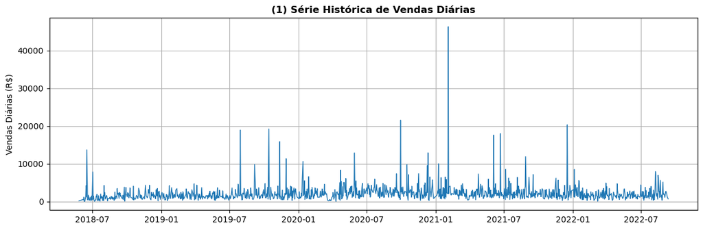

```python
# Série Histórica de Vendas Diárias
plt.figure(figsize=(12,4))
plt.plot(inputProphet, linewidth=1)
plt.title('(1) Série Histórica de Vendas Diárias',fontweight='bold')
plt.ylabel('Vendas Diárias (R$)')
plt.tight_layout()
plt.grid()
```

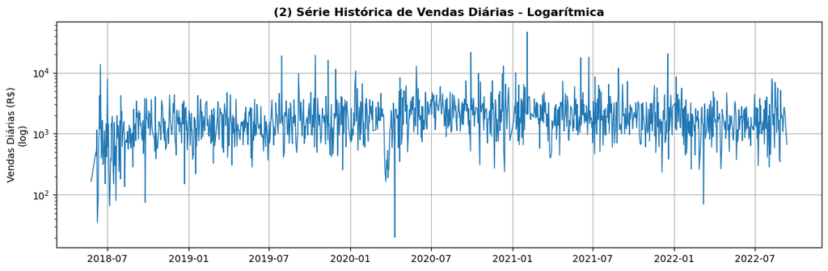

```python
# Série Histórica de Vendas Diárias - Logarítmica
plt.figure(figsize=(12,4))
plt.plot(inputProphet, linewidth=1)
plt.yscale("log")
plt.title('(2) Série Histórica de Vendas Diárias - Logarítmica',fontweight='bold')
plt.ylabel('Vendas Diárias (R$)\n(log)')
plt.tight_layout()
plt.grid()
```

Os gráficos **(3)**, **(4)**, **(5)** e **(6)** têm como objetivo comparar, em diferentes escalas (diário, diário logarítmo, semanal e mensal respectivamente), as vendas nos anos de 2018, 2019, 2020, 2021 e 2022. A necessidade do gráfico logarítmico **(4)** justificou-se pelo mesmo motivo do gráfico **(2)**.  
Nesses gráficos, há uma dificuldade em observar correlações expressivas entre anos e sazonalidades. Os gráficos diários **(3)** e **(4)** são extremamente ruidosos; enquanto os **(5)** e **(6)** são inconclusivos, com uma leve exceção no gráfico **(6)** no que tange aos meses de janeiro, fevereiro e dezembro. Há, nesse intervalo de tempo, um pequeno aumento médio nas vendas, provavelmente relacionado ao natal e ao ano novo.  
Além disso, os gráficos **(4)**, **(5)** e **(6)** conseguem evidenciar bem o baixo faturamento em 2018 ocasionado pela abertura da loja, período de adaptação e conquista de mercado.

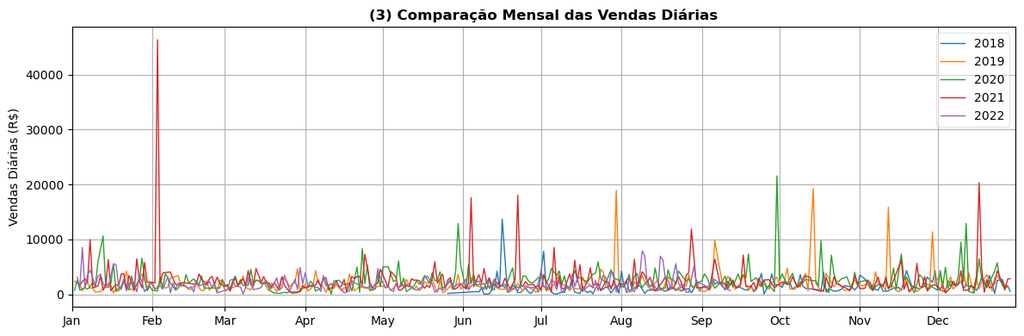

```python
# Comparação Mensal das Vendas Diárias
fig, ax = plt.subplots(figsize=(12,4))
ax.plot(inputProphet[inputProphet.index.year==2018].index                           , inputProphet[inputProphet.index.year==2018]['Total do Item'], label = '2018', linewidth=1)
ax.plot(inputProphet[inputProphet.index.year==2019].index - np.timedelta64( 365,'D'), inputProphet[inputProphet.index.year==2019]['Total do Item'], label = '2019', linewidth=1)
ax.plot(inputProphet[inputProphet.index.year==2020].index - np.timedelta64( 730,'D'), inputProphet[inputProphet.index.year==2020]['Total do Item'], label = '2020', linewidth=1)
ax.plot(inputProphet[inputProphet.index.year==2021].index - np.timedelta64(1096,'D'), inputProphet[inputProphet.index.year==2021]['Total do Item'], label = '2021', linewidth=1)
ax.plot(inputProphet[inputProphet.index.year==2022].index - np.timedelta64(1461,'D'), inputProphet[inputProphet.index.year==2022]['Total do Item'], label = '2022', linewidth=1)
ax.set_title('(3) Comparação Mensal das Vendas Diárias',fontweight='bold')
ax.set_ylabel('Vendas Diárias (R$)')
ax.xaxis.set_major_locator(mdates.MonthLocator())
ax.xaxis.set_major_formatter(mdates.DateFormatter('%b'))
ax.set_xlim(np.datetime64('2018-01-01T00:00:00.000000000'),np.datetime64('2018-12-31T00:00:00.000000000'))
plt.tight_layout()
plt.legend(framealpha=0.5)
plt.grid()
```

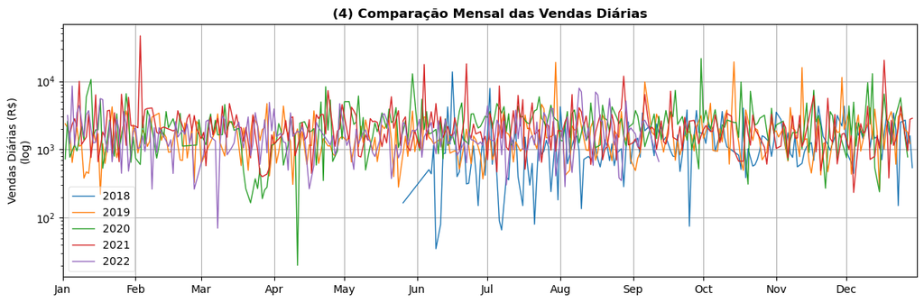

```python
# Comparação Mensal das Vendas Diárias
fig, ax = plt.subplots(figsize=(12,4))
ax.plot(inputProphet[inputProphet.index.year==2018].index                           , inputProphet[inputProphet.index.year==2018]['Total do Item'], label = '2018', linewidth=1)
ax.plot(inputProphet[inputProphet.index.year==2019].index - np.timedelta64( 365,'D'), inputProphet[inputProphet.index.year==2019]['Total do Item'], label = '2019', linewidth=1)
ax.plot(inputProphet[inputProphet.index.year==2020].index - np.timedelta64( 730,'D'), inputProphet[inputProphet.index.year==2020]['Total do Item'], label = '2020', linewidth=1)
ax.plot(inputProphet[inputProphet.index.year==2021].index - np.timedelta64(1096,'D'), inputProphet[inputProphet.index.year==2021]['Total do Item'], label = '2021', linewidth=1)
ax.plot(inputProphet[inputProphet.index.year==2022].index - np.timedelta64(1461,'D'), inputProphet[inputProphet.index.year==2022]['Total do Item'], label = '2022', linewidth=1)
ax.set_title('(4) Comparação Mensal das Vendas Diárias',fontweight='bold')
ax.set_ylabel('Vendas Diárias (R$)\n(log)')
ax.xaxis.set_major_locator(mdates.MonthLocator())
ax.xaxis.set_major_formatter(mdates.DateFormatter('%b'))
ax.set_xlim(np.datetime64('2018-01-01T00:00:00.000000000'),np.datetime64('2018-12-31T00:00:00.000000000'))
plt.yscale("log")
plt.tight_layout()
plt.legend(framealpha=0.5)
plt.grid()
```

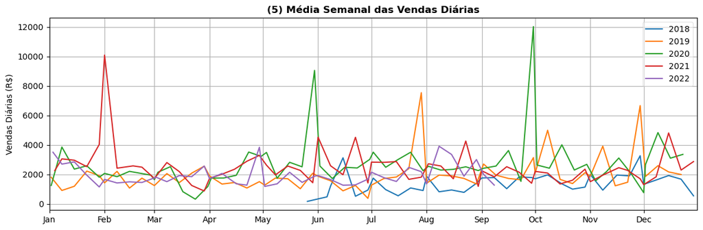

```python
# Média Semanal das Vendas Diárias
temp = df[['datetime','weeknum']]
droplist = []
for i in range(len(temp)-1):
    if temp['weeknum'].iloc[i+1] == temp['weeknum'].iloc[i]:
        droplist.append(i+1)
temp = temp.drop(droplist,axis=0).reset_index(drop=True)
df_ = df.groupby(['year','month','weeknum']).agg(np.mean).drop(['weekday','day'],axis=1)
df_['date'] = temp.datetime.values

fig, ax = plt.subplots(figsize=(12,4))
ax.plot(df_.loc[2018].date                           , df_.loc[2018].value, label = '2018')
ax.plot(df_.loc[2019].date - np.timedelta64( 365,'D'), df_.loc[2019].value, label = '2019')
ax.plot(df_.loc[2020].date - np.timedelta64( 730,'D'), df_.loc[2020].value, label = '2020')
ax.plot(df_.loc[2021].date - np.timedelta64(1096,'D'), df_.loc[2021].value, label = '2021')
ax.plot(df_.loc[2022].date - np.timedelta64(1461,'D'), df_.loc[2022].value, label = '2022')
ax.set_title('(5) Média Semanal das Vendas Diárias',fontweight='bold')
ax.set_ylabel('Vendas Diárias (R$)')
ax.xaxis.set_major_locator(mdates.MonthLocator())
ax.xaxis.set_major_formatter(mdates.DateFormatter('%b'))
ax.set_xlim(np.datetime64('2018-01-01T00:00:00.000000000'),np.datetime64('2018-12-31T00:00:00.000000000'))
#plt.yscale("log")
plt.tight_layout()
plt.legend(framealpha=0.5)
plt.grid()
```

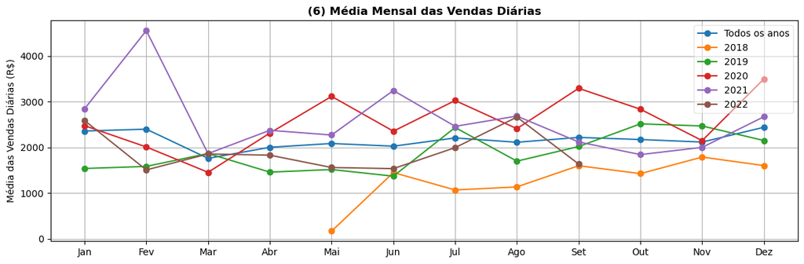

```python
# Média Mensal das Vendas Diárias
plt.figure(figsize=(12,4))
plt.plot(df.groupby(['month']).agg(np.mean).drop(['weekday','day','year','weeknum','qtd'],axis=1), marker='o', label='Todos os anos')
plt.plot(df.groupby(['year','month']).agg(np.mean).drop(['weekday','day','weeknum','qtd'],axis=1).loc[2018], marker='o', label='2018')
plt.plot(df.groupby(['year','month']).agg(np.mean).drop(['weekday','day','weeknum','qtd'],axis=1).loc[2019], marker='o', label='2019')
plt.plot(df.groupby(['year','month']).agg(np.mean).drop(['weekday','day','weeknum','qtd'],axis=1).loc[2020], marker='o', label='2020')
plt.plot(df.groupby(['year','month']).agg(np.mean).drop(['weekday','day','weeknum','qtd'],axis=1).loc[2021], marker='o', label='2021')
plt.plot(df.groupby(['year','month']).agg(np.mean).drop(['weekday','day','weeknum','qtd'],axis=1).loc[2022], marker='o', label='2022')
plt.title('(6) Média Mensal das Vendas Diárias',fontweight='bold')
plt.ylabel('Média das Vendas Diárias (R$)')
plt.xticks(np.arange(1, 13, 1))
locs, _=plt.xticks()
plt.xticks(locs,['Jan','Fev','Mar','Abr','Mai','Jun','Jul','Ago','Set','Out','Nov','Dez'])
plt.tight_layout()
plt.legend(framealpha=0.5)
plt.grid()
```

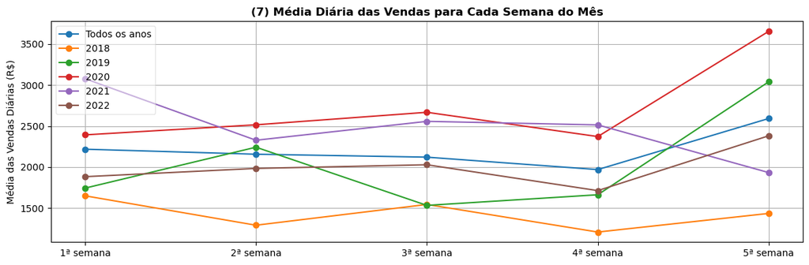

```python
# Média Diária das Vendas para Cada Semana do Mês
plt.figure(figsize=(12,4))
plt.plot(df.groupby(['weeknum']).agg(np.mean).drop(['weekday','day','month','year','qtd'],axis=1), marker='o', label='Todos os anos')
plt.plot(df.groupby(['year','weeknum']).agg(np.mean).drop(['weekday','day','month','qtd'],axis=1).loc[2018], marker='o', label='2018')
plt.plot(df.groupby(['year','weeknum']).agg(np.mean).drop(['weekday','day','month','qtd'],axis=1).loc[2019], marker='o', label='2019')
plt.plot(df.groupby(['year','weeknum']).agg(np.mean).drop(['weekday','day','month','qtd'],axis=1).loc[2020], marker='o', label='2020')
plt.plot(df.groupby(['year','weeknum']).agg(np.mean).drop(['weekday','day','month','qtd'],axis=1).loc[2021], marker='o', label='2021')
plt.plot(df.groupby(['year','weeknum']).agg(np.mean).drop(['weekday','day','month','qtd'],axis=1).loc[2022], marker='o', label='2022')
plt.title('(7) Média Diária das Vendas para Cada Semana do Mês',fontweight='bold')
plt.ylabel('Média das Vendas Diárias (R$)')
plt.xticks(np.arange(1, 6, 1))
locs, _=plt.xticks()
plt.xticks(locs, ['1ª semana','2ª semana','3ª semana','4ª semana','5ª semana'])
plt.tight_layout()
plt.legend(framealpha=0.5)
plt.grid()
```

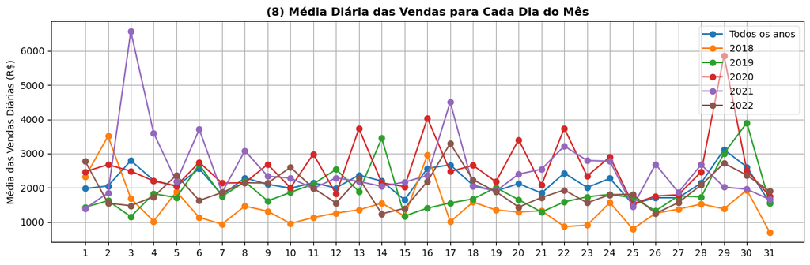

```python
# Média Diária das Vendas para Cada Dia do Mês
plt.figure(figsize=(12,4))
plt.plot(df.groupby(['day']).agg(np.mean).drop(['weekday','month','year','weeknum','qtd'],axis=1), marker='o', label='Todos os anos')
plt.plot(df.groupby(['year','day']).agg(np.mean).drop(['weekday','month','weeknum','qtd'],axis=1).loc[2018], marker='o', label='2018')
plt.plot(df.groupby(['year','day']).agg(np.mean).drop(['weekday','month','weeknum','qtd'],axis=1).loc[2019], marker='o', label='2019')
plt.plot(df.groupby(['year','day']).agg(np.mean).drop(['weekday','month','weeknum','qtd'],axis=1).loc[2020], marker='o', label='2020')
plt.plot(df.groupby(['year','day']).agg(np.mean).drop(['weekday','month','weeknum','qtd'],axis=1).loc[2021], marker='o', label='2021')
plt.plot(df.groupby(['year','day']).agg(np.mean).drop(['weekday','month','weeknum','qtd'],axis=1).loc[2022], marker='o', label='2022')
plt.title('(8) Média Diária das Vendas para Cada Dia do Mês',fontweight='bold')
plt.ylabel('Média das Vendas Diárias (R$)')
plt.xticks(np.arange(1, 32, 1))
plt.tight_layout()
plt.legend(framealpha=0.5)
plt.grid()
```

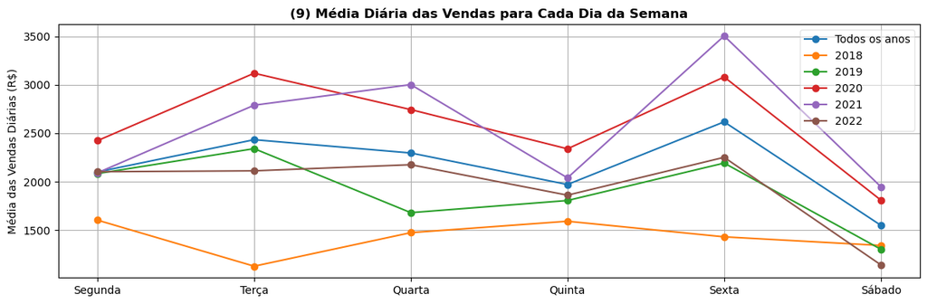

```python
# Média Diária das Vendas para Cada Dia da Semana
plt.figure(figsize=(12,4))
plt.plot(df.groupby('weekday').agg(np.mean).drop(['year','weeknum','day','month','qtd'],axis=1).drop([6]), marker='o', label='Todos os anos')
plt.plot(df.groupby(['year','weekday']).agg(np.mean).drop(['weeknum','day','month','qtd'],axis=1).loc[2018].drop([6]), marker='o', label='2018')
plt.plot(df.groupby(['year','weekday']).agg(np.mean).drop(['weeknum','day','month','qtd'],axis=1).loc[2019].drop([6]), marker='o', label='2019')
plt.plot(df.groupby(['year','weekday']).agg(np.mean).drop(['weeknum','day','month','qtd'],axis=1).loc[2020], marker='o', label='2020')
plt.plot(df.groupby(['year','weekday']).agg(np.mean).drop(['weeknum','day','month','qtd'],axis=1).loc[2021].drop([6]), marker='o', label='2021')
plt.plot(df.groupby(['year','weekday']).agg(np.mean).drop(['weeknum','day','month','qtd'],axis=1).loc[2022], marker='o', label='2022')
plt.title('(9) Média Diária das Vendas para Cada Dia da Semana',fontweight='bold')
plt.ylabel('Média das Vendas Diárias (R$)')
plt.xticks(np.arange(0, 6, 1))
locs, _ = plt.xticks()
plt.xticks(locs, ['Segunda','Terça','Quarta','Quinta','Sexta','Sábado'])
plt.tight_layout()
plt.legend(framealpha=0.5)
plt.grid()
```

Os gráficos **(10)**, **(11)** e **(12)** têm como objetivo mostrar a distribuição da quantidade diária de clientes que a loja recebe, tanto historicamente quanto ao longo do ano, respectivamente. Como o gráfico **(11)** é muito ruidoso, foi aplicada uma média móvel nos dados (gráfico **(12)**). Dessa forma, é possível identificar comportamentos da curva semelhantes nos anos de 2019 e 2022, e 2020 e 2021. Já o gráfico **(13)** mostra a distrifuição em frequência da quantidade de clientes que compram com a empresa. As distribuições são bem semelhantes no intervalo de ocorrência, e todas com desvio padrão alto, o que corrobora a ruidosidade do gráfico **(11)**.

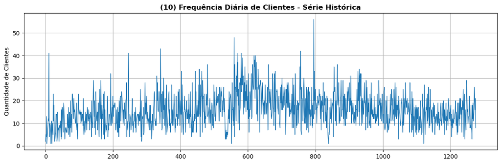

```python
# Frequência Diária de Clientes - Série Histórica
plt.figure(figsize=(12,4))
plt.plot(df['qtd'], linewidth=1)
plt.title('(10) Frequência Diária de Clientes - Série Histórica',fontweight='bold')
plt.ylabel('Quantidade de Clientes')
plt.tight_layout()
plt.grid()
```

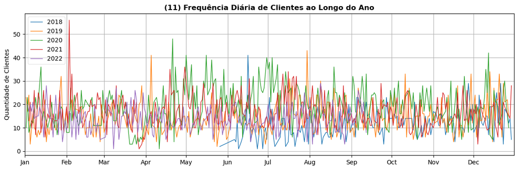

```python
# (11) Frequência Diária de Clientes ao Longo do Ano
fig, ax = plt.subplots(figsize=(12,4))
ax.plot(df[df['datetime'].dt.year==2018]['datetime']                           , df[df['datetime'].dt.year==2018]['qtd'], linewidth = 1, label = '2018')
ax.plot(df[df['datetime'].dt.year==2019]['datetime'] - np.timedelta64( 365,'D'), df[df['datetime'].dt.year==2019]['qtd'], linewidth = 1, label = '2019')
ax.plot(df[df['datetime'].dt.year==2020]['datetime'] - np.timedelta64( 730,'D'), df[df['datetime'].dt.year==2020]['qtd'], linewidth = 1, label = '2020')
ax.plot(df[df['datetime'].dt.year==2021]['datetime'] - np.timedelta64(1096,'D'), df[df['datetime'].dt.year==2021]['qtd'], linewidth = 1, label = '2021')
ax.plot(df[df['datetime'].dt.year==2022]['datetime'] - np.timedelta64(1461,'D'), df[df['datetime'].dt.year==2022]['qtd'], linewidth = 1, label = '2022')
ax.set_title('(11) Frequência Diária de Clientes ao Longo do Ano',fontweight='bold')
ax.set_ylabel('Quantidade de Clientes')
ax.xaxis.set_major_locator(mdates.MonthLocator())
ax.xaxis.set_major_formatter(mdates.DateFormatter('%b'))
ax.set_xlim(np.datetime64('2018-01-01T00:00:00.000000000'),np.datetime64('2018-12-31T00:00:00.000000000'))
plt.tight_layout()
plt.legend(framealpha=0.5)
plt.grid()
```

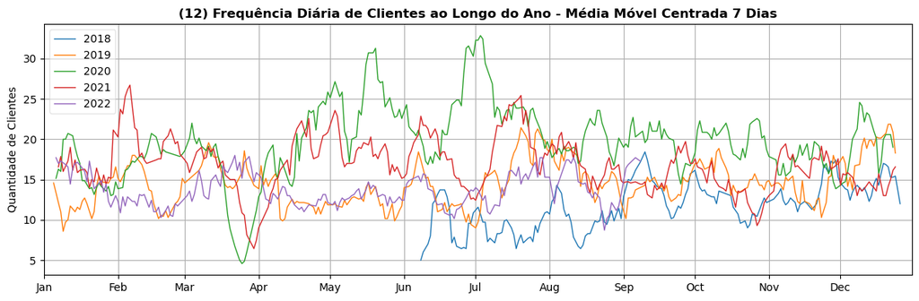

```python
# (12) Frequência Diária de Clientes ao Longo do Ano - Média Móvel Centrada 7 Dias
fig, ax = plt.subplots(figsize=(12,4))
ax.plot(df[df['datetime'].dt.year==2018]['datetime']                           , df[df['datetime'].dt.year==2018]['qtd'].rolling(window=7,center=True).mean(), linewidth = 1, label = '2018')
ax.plot(df[df['datetime'].dt.year==2019]['datetime'] - np.timedelta64( 365,'D'), df[df['datetime'].dt.year==2019]['qtd'].rolling(window=7,center=True).mean(), linewidth = 1, label = '2019')
ax.plot(df[df['datetime'].dt.year==2020]['datetime'] - np.timedelta64( 730,'D'), df[df['datetime'].dt.year==2020]['qtd'].rolling(window=7,center=True).mean(), linewidth = 1, label = '2020')
ax.plot(df[df['datetime'].dt.year==2021]['datetime'] - np.timedelta64(1096,'D'), df[df['datetime'].dt.year==2021]['qtd'].rolling(window=7,center=True).mean(), linewidth = 1, label = '2021')
ax.plot(df[df['datetime'].dt.year==2022]['datetime'] - np.timedelta64(1461,'D'), df[df['datetime'].dt.year==2022]['qtd'].rolling(window=7,center=True).mean(), linewidth = 1, label = '2022')
ax.set_title('(12) Frequência Diária de Clientes ao Longo do Ano - Média Móvel Centrada 7 Dias',fontweight='bold')
ax.set_ylabel('Quantidade de Clientes')
ax.xaxis.set_major_locator(mdates.MonthLocator())
ax.xaxis.set_major_formatter(mdates.DateFormatter('%b'))
ax.set_xlim(np.datetime64('2018-01-01T00:00:00.000000000'),np.datetime64('2018-12-31T00:00:00.000000000'))
plt.tight_layout()
plt.legend(framealpha=0.5)
plt.grid()
```

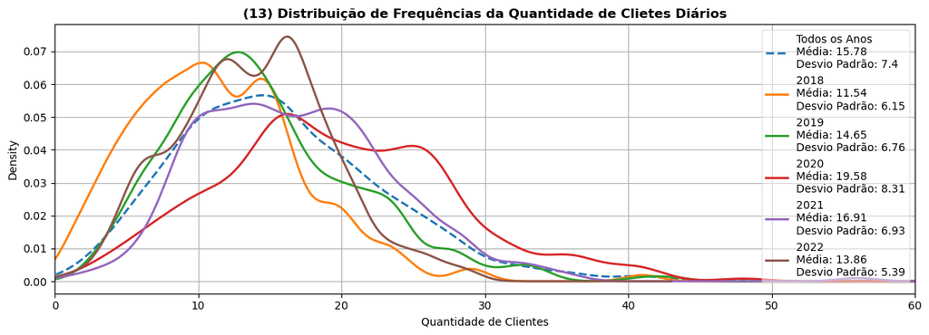

```python
# (13) Distribuição de Frequências da Quantidade de Clietes Diários
plt.figure(figsize=(12,4.4))
bw = 0.2
df['qtd']                              .plot.kde(bw_method=bw, linewidth = 2, label = f"Todos os Anos\nMédia: {np.round(df['qtd'].mean(),2)}\nDesvio Padrão: {np.round(df['qtd'].std(),2)}", linestyle = 'dashed')
df[df['datetime'].dt.year==2018]['qtd'].plot.kde(bw_method=bw, linewidth = 2, label = f"2018\nMédia: {np.round(df[df['datetime'].dt.year==2018]['qtd'].mean(),2)}\nDesvio Padrão: {np.round(df[df['datetime'].dt.year==2018]['qtd'].std(),2)}")
df[df['datetime'].dt.year==2019]['qtd'].plot.kde(bw_method=bw, linewidth = 2, label = f"2019\nMédia: {np.round(df[df['datetime'].dt.year==2019]['qtd'].mean(),2)}\nDesvio Padrão: {np.round(df[df['datetime'].dt.year==2019]['qtd'].std(),2)}")
df[df['datetime'].dt.year==2020]['qtd'].plot.kde(bw_method=bw, linewidth = 2, label = f"2020\nMédia: {np.round(df[df['datetime'].dt.year==2020]['qtd'].mean(),2)}\nDesvio Padrão: {np.round(df[df['datetime'].dt.year==2020]['qtd'].std(),2)}")
df[df['datetime'].dt.year==2021]['qtd'].plot.kde(bw_method=bw, linewidth = 2, label = f"2021\nMédia: {np.round(df[df['datetime'].dt.year==2021]['qtd'].mean(),2)}\nDesvio Padrão: {np.round(df[df['datetime'].dt.year==2021]['qtd'].std(),2)}")
df[df['datetime'].dt.year==2022]['qtd'].plot.kde(bw_method=bw, linewidth = 2, label = f"2022\nMédia: {np.round(df[df['datetime'].dt.year==2022]['qtd'].mean(),2)}\nDesvio Padrão: {np.round(df[df['datetime'].dt.year==2022]['qtd'].std(),2)}")
plt.xlim(0,60)
plt.title('(13) Distribuição de Frequências da Quantidade de Clietes Diários', fontweight='bold')
plt.xlabel('Quantidade de Clientes')
plt.tight_layout()
plt.legend(framealpha=0.5)
plt.grid()
```

Os gráficos **(14)** e **(15)** têm como objetivo evidenciar a frequência diária média da quantidade de clientes em curtos intervalo temporal, respectivamente dias da semana e semanas do mês. O gráfico **(14)** mostrou-se bem homogêneo ao longo da semana, com somente uma queda no sábado. Entretanto esse comportamento é esperado, visto que a loja só abre meio período durante o sábado. Além disso, é interessante ressaltar que o gráfico **(9)** mostrou uma diferença significativa na quinta-feira (poucas vendas) e na sexta-feira (muitas vendas), e essa distinção não aparece na frequência diária de clientes. Ou seja, por mais que o fluxo de clientes não varie muito, eles costumam comprar produtos mais caros na sexta-feira e mais baratos na quinta-feira. O gráfico **(15)**, por sua vez, evidencia que não há diferenças relevantes no que tange ao fluxo de clientes ao longo das semanas do mês.

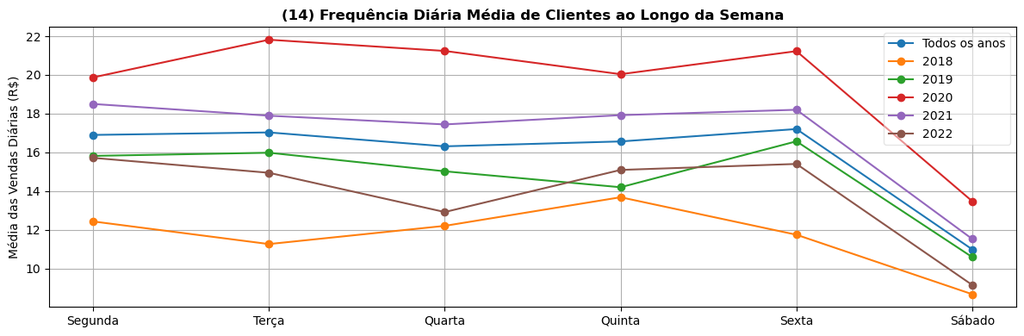

```python
# (14) Frequência Diária Média de Clientes ao Longo da Semana
plt.figure(figsize=(12,4))
plt.plot(df.groupby('weekday').agg(np.mean).drop(['year','weeknum','day','month','value'],axis=1).drop([6]), marker='o', label='Todos os anos')
plt.plot(df.groupby(['year','weekday']).agg(np.mean).drop(['weeknum','day','month','value'],axis=1).loc[2018].drop([6]), marker='o', label='2018')
plt.plot(df.groupby(['year','weekday']).agg(np.mean).drop(['weeknum','day','month','value'],axis=1).loc[2019].drop([6]), marker='o', label='2019')
plt.plot(df.groupby(['year','weekday']).agg(np.mean).drop(['weeknum','day','month','value'],axis=1).loc[2020], marker='o', label='2020')
plt.plot(df.groupby(['year','weekday']).agg(np.mean).drop(['weeknum','day','month','value'],axis=1).loc[2021].drop([6]), marker='o', label='2021')
plt.plot(df.groupby(['year','weekday']).agg(np.mean).drop(['weeknum','day','month','value'],axis=1).loc[2022], marker='o', label='2022')
plt.title('(14) Frequência Diária Média de Clientes ao Longo da Semana',fontweight='bold')
plt.ylabel('Média das Vendas Diárias (R$)')
plt.xticks(np.arange(0, 6, 1))
locs, _ = plt.xticks()
plt.xticks(locs, ['Segunda','Terça','Quarta','Quinta','Sexta','Sábado'])
plt.tight_layout()
plt.legend(framealpha=0.5)
plt.grid()
```

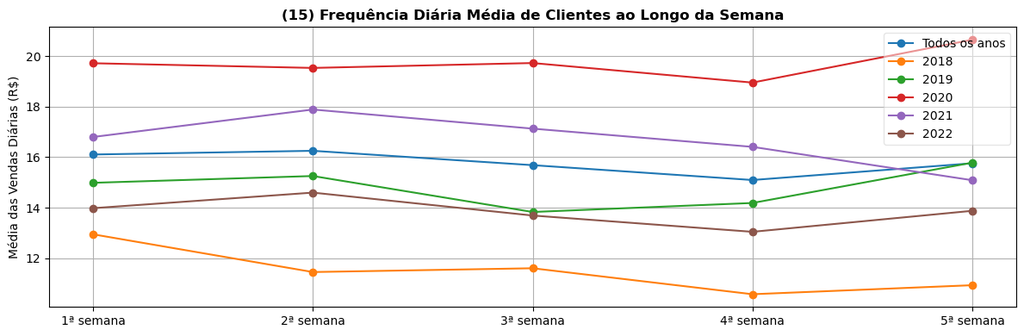

```python
# (15) Frequência Diária Média de Clientes ao Longo da Semana
plt.figure(figsize=(12,4))
plt.plot(df.groupby('weeknum').agg(np.mean).drop(['year','weekday','day','month','value'],axis=1), marker='o', label='Todos os anos')
plt.plot(df.groupby(['year','weeknum']).agg(np.mean).drop(['weekday','day','month','value'],axis=1).loc[2018], marker='o', label='2018')
plt.plot(df.groupby(['year','weeknum']).agg(np.mean).drop(['weekday','day','month','value'],axis=1).loc[2019], marker='o', label='2019')
plt.plot(df.groupby(['year','weeknum']).agg(np.mean).drop(['weekday','day','month','value'],axis=1).loc[2020], marker='o', label='2020')
plt.plot(df.groupby(['year','weeknum']).agg(np.mean).drop(['weekday','day','month','value'],axis=1).loc[2021], marker='o', label='2021')
plt.plot(df.groupby(['year','weeknum']).agg(np.mean).drop(['weekday','day','month','value'],axis=1).loc[2022], marker='o', label='2022')
plt.title('(15) Frequência Diária Média de Clientes ao Longo da Semana',fontweight='bold')
plt.ylabel('Média das Vendas Diárias (R$)')
plt.xticks(np.arange(1, 6, 1))
locs, _=plt.xticks()
plt.xticks(locs, ['1ª semana','2ª semana','3ª semana','4ª semana','5ª semana'])
plt.tight_layout()
plt.legend(framealpha=0.5)
plt.grid()
```

```python
#from sklearn.metrics import mean_squared_error
#from math import sqrt
#rmse = sqrt(mean_squared_error(validacao.y, forecast.yhat))
#print('Teste RSME: %.3f' % rmse)
```

```python
#from efficient_apriori import apriori

#itemsets, rules = apriori([tuple(x) for x in input_transaction.Produto.to_list()], min_support=0.0001, min_confidence=0.1)
#print(len(rules))
```

```python
# Print out every rule with 2 items on the left hand side,
# 1 item on the right hand side, sorted by lift
# rules_rhs = filter(lambda rule: len(rule.lhs) == 2 and len(rule.rhs) == 1, rules)

#rules_rhs = rules
#for rule in sorted(rules_rhs, key=lambda rule: rule.lift, reverse=True):
#  print(rule)  # Prints the rule and its confidence, support, lift, ...
```